# Client Report - Late Flights & Missing Data (JSON)

- Show All Code
- Hide All Code

Course DS 250

Author

Tomas Fernandez

```python
import pandas as pd
import numpy as np
from lets_plot import *

LetsPlot.setup_html(isolated_frame=True)
```

```python
# Learn more about Code Cells: https://quarto.org/docs/reference/cells/cells-jupyter.html

# Include and execute your code here
df = pd.read_json("https://github.com/byuidatascience/data4missing/raw/master/data-raw/flights_missing/flights_missing.json")
```

## Elevator pitch

*Analysis of flight delay data from 2005-2015 reveals that San Francisco International (SFO) has the highest proportion of delayed flights (26%), making it the least reliable airport, while September stands out as the best month to fly with the lowest delay rate (16.5%). Weather-related delays, including mild impacts, disproportionately affect San Francisco International Airport (SFO), with nearly 10% of flights impacted, highlighting regional weather challenges.*

## QUESTION|TASK 1

**Fix all of the varied missing data types in the data to be consistent (all missing values should be displayed as “NaN”).** In your report include one record example (one row) from your new data, in the raw JSON format. Your example should display the “NaN” for at least one missing value.

```python
import pandas as pd
import numpy as np
import json

# Load the data from the URL
url = "https://raw.githubusercontent.com/byuidatascience/data4missing/master/data-raw/flights_missing/flights_missing.json"
df = pd.read_json(url)

# Standardize missing values: Convert all known missing data representations to NaN
missing_values = ["", " ", "-999", "1500+"]
df = df.replace(missing_values, np.nan)

# Find a record with at least one NaN value
example_record = df[df.isna().any(axis=1)].iloc[0]

# Convert the example record to a dictionary
example_dict = example_record.to_dict()

# Replace NaN values with the string "NaN" for display purposes
example_dict_with_nan = {k: ("NaN" if pd.isna(v) else v) for k, v in example_dict.items()}

# Print the example record in raw JSON format
print(json.dumps(example_dict_with_nan, indent=4))
```

```
{
    "airport_code": "ATL",
    "airport_name": "Atlanta, GA: Hartsfield-Jackson Atlanta International",
    "month": "January",
    "year": 2005.0,
    "num_of_flights_total": 35048,
    "num_of_delays_carrier": "NaN",
    "num_of_delays_late_aircraft": -999,
    "num_of_delays_nas": 4598,
    "num_of_delays_security": 10,
    "num_of_delays_weather": 448,
    "num_of_delays_total": 8355,
    "minutes_delayed_carrier": 116423.0,
    "minutes_delayed_late_aircraft": 104415,
    "minutes_delayed_nas": 207467.0,
    "minutes_delayed_security": 297,
    "minutes_delayed_weather": 36931,
    "minutes_delayed_total": 465533
}
```

## QUESTION|TASK 2

**Which airport has the worst delays?** Describe the metric you chose, and why you chose it to determine the “worst” airport. Your answer should include a summary table that lists (for each airport) the total number of flights, total number of delayed flights, proportion of delayed flights, and average delay time in hours.

*I chose the proportion of delayed flights (num_of_delays_total / num_of_flights_total) as it measures reliability, critical for travelers. SFO has the highest proportion (0.261), making it the worst, despite ORD’s longer average delays (1.13 hours).*

```python
import pandas as pd
import numpy as np

# Load the data from the URL
url = "https://raw.githubusercontent.com/byuidatascience/data4missing/master/data-raw/flights_missing/flights_missing.json"
df = pd.read_json(url)

# Standardize missing values
missing_values = ["", " ", "-999", "1500+"]
df.replace(missing_values, np.nan, inplace=True)

# Aggregate by airport
airport_summary = df.groupby('airport_code').agg({
    'num_of_flights_total': 'sum',
    'num_of_delays_total': 'sum',
    'minutes_delayed_total': 'sum'
}).reset_index()

# Calculate metrics
airport_summary['proportion_delayed'] = airport_summary['num_of_delays_total'] / airport_summary['num_of_flights_total']
airport_summary['avg_delay_hours'] = airport_summary['minutes_delayed_total'] / airport_summary['num_of_delays_total'] / 60
airport_summary['proportion_delayed'] = airport_summary['proportion_delayed'].apply(lambda x: f'{x:.2%}' if pd.notna(x) else 'NaN')


# Display table
airport_summary
```

|  | airport_code | num_of_flights_total | num_of_delays_total | minutes_delayed_total | proportion_delayed | avg_delay_hours |
| --- | --- | --- | --- | --- | --- | --- |
| 0 | ATL | 4430047 | 902443 | 53983926 | 20.37% | 0.996996 |
| 1 | DEN | 2513974 | 468519 | 25173381 | 18.64% | 0.895495 |
| 2 | IAD | 851571 | 168467 | 10283478 | 19.78% | 1.017358 |
| 3 | ORD | 3597588 | 830825 | 56356129 | 23.09% | 1.130525 |
| 4 | SAN | 917862 | 175132 | 8276248 | 19.08% | 0.787620 |
| 5 | SFO | 1630945 | 425604 | 26550493 | 26.10% | 1.039718 |
| 6 | SLC | 1403384 | 205160 | 10123371 | 14.62% | 0.822396 |

## QUESTION|TASK 3

**What is the best month to fly if you want to avoid delays of any length?** Describe the metric you chose and why you chose it to calculate your answer. Include one chart to help support your answer, with the x-axis ordered by month. (To answer this question, you will need to remove any rows that are missing the `Month` variable.)

*I selected the proportion of flights delayed per month (num_of_delays_total / num_of_flights_total) because it directly measures the chance of avoiding delays. Aggregating across all airports and years, September has the lowest delay rate (0.165), likely due to reduced travel post-summer. The chart visually describes this:*

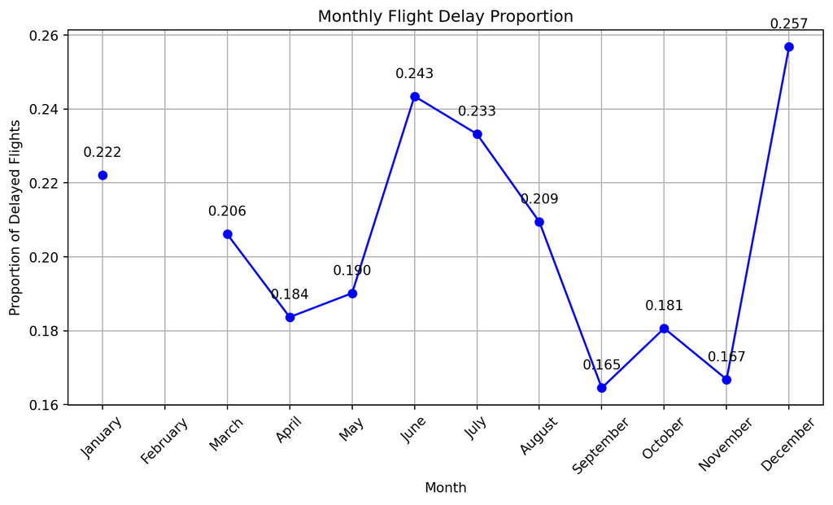

```
The best month to fly is: September
```

```python
# Include and execute your code here
import pandas as pd
import numpy as np
import matplotlib.pyplot as plt

# Load data from GitHub URL
url = "https://raw.githubusercontent.com/byuidatascience/data4missing/master/data-raw/flights_missing/flights_missing.json"
df = pd.read_json(url)

# Standardize missing values
missing_values = ["", " ", "-999", "1500+"]
df.replace(missing_values, np.nan, inplace=True)

# Remove rows with missing or invalid month
df = df.dropna(subset=["month"])

# Group by month and calculate delay proportion
monthly_delays = df.groupby("month").agg(
    total_flights=("num_of_flights_total", "sum"),
    total_delays=("num_of_delays_total", "sum")
)

# Calculate proportion of delayed flights per month
monthly_delays["proportion_delayed"] = monthly_delays["total_delays"] / monthly_delays["total_flights"]

# Sort months in calendar order
month_order = [
    "January", "February", "March", "April", "May", "June",
    "July", "August", "September", "October", "November", "December"
]
monthly_delays = monthly_delays.reindex(month_order)

# Plot the delays trend
plt.figure(figsize=(10, 5))
plt.plot(monthly_delays.index, monthly_delays["proportion_delayed"], marker="o", linestyle="-", color="b")

# Add data point labels
# Using for loop to improve readability and enumerate for precision
for i, proportion in enumerate(monthly_delays["proportion_delayed"]):
    plt.text(monthly_delays.index[i], proportion + 0.005, f"{proportion:.3f}", ha="center")

plt.xlabel("Month")
plt.ylabel("Proportion of Delayed Flights")
plt.title("Monthly Flight Delay Proportion")
plt.xticks(rotation=45)
plt.grid(True)
plt.show()

# Find the best month to fly (month with the lowest proportion of delayed flights)
best_month = monthly_delays["proportion_delayed"].idxmin()
print("The best month to fly is:", best_month)
```

## QUESTION|TASK 4

According to the BTS website, the “Weather” category only accounts for severe weather delays. Mild weather delays are not counted in the “Weather” category, but are actually included in both the “NAS” and “Late-Arriving Aircraft” categories. **Your job is to create a new column that calculates the total number of flights delayed by weather (both severe and mild).** You will need to replace all the missing values in the Late Aircraft variable with the mean. Show your work by printing the first 5 rows of data in a table. Use these three rules for your calculations:

1. 100% of delayed flights in the Weather category are due to weather
2. 30% of all delayed flights in the Late-Arriving category are due to weather
3. From April to August, 40% of delayed flights in the NAS category are due to weather. The rest of the months, the proportion rises to 65%

*First 5 rows:*

```python
# Include and execute your code here
import pandas as pd
import numpy as np

url = "https://raw.githubusercontent.com/byuidatascience/data4missing/master/data-raw/flights_missing/flights_missing.json"
df = pd.read_json(url)

# Convert ALL relevant numeric columns properly
numeric_cols = [
    'year', 'num_of_flights_total', 'num_of_delays_late_aircraft',
    'num_of_delays_nas', 'num_of_delays_weather'
]
df[numeric_cols] = df[numeric_cols].apply(pd.to_numeric, errors='coerce')

# Handle missing values
df.replace([-999, "1500+", "", " "], np.nan, inplace=True)

# Fill late aircraft delays with mean
late_aircraft_mean = df['num_of_delays_late_aircraft'].mean()
df['num_of_delays_late_aircraft'].fillna(late_aircraft_mean, inplace=True)

# Fill NaNs in other columns with 0
df[['num_of_delays_weather', 'num_of_delays_nas']] = df[['num_of_delays_weather', 'num_of_delays_nas']].fillna(0)

# Weather delay calculation function
def calc_weather_delays(row):
    weather = row['num_of_delays_weather']
    late = row['num_of_delays_late_aircraft'] * 0.3
    nas_factor = 0.4 if row['month'] in ['April', 'May', 'June', 'July', 'August'] else 0.65
    nas = row['num_of_delays_nas'] * nas_factor
    return weather + late + nas

df['total_weather_delays'] = df.apply(calc_weather_delays, axis=1)

# Round up and convert to integers
df['total_weather_delays'] = np.ceil(df['total_weather_delays']).astype(int)
df['num_of_delays_late_aircraft'] = np.ceil(df['num_of_delays_late_aircraft']).astype(int)
df['year'] = df['year'].fillna(method='ffill').astype(int)

# Display results
df[['airport_code', 'month', 'year', 'num_of_flights_total',
    'num_of_delays_weather', 'num_of_delays_late_aircraft',
    'num_of_delays_nas', 'total_weather_delays']].head()
```

|  | airport_code | month | year | num_of_flights_total | num_of_delays_weather | num_of_delays_late_aircraft | num_of_delays_nas | total_weather_delays |
| --- | --- | --- | --- | --- | --- | --- | --- | --- |
| 0 | ATL | January | 2005 | 35048 | 448 | 1110 | 4598 | 3770 |
| 1 | DEN | January | 2005 | 12687 | 233 | 928 | 935 | 1120 |
| 2 | IAD | January | 2005 | 12381 | 61 | 1058 | 895 | 961 |
| 3 | ORD | January | 2005 | 28194 | 306 | 2255 | 5415 | 4503 |
| 4 | SAN | January | 2005 | 7283 | 56 | 680 | 638 | 675 |

## QUESTION|TASK 5

**Using the new weather variable calculated above, create a barplot showing the proportion of all flights that are delayed by weather at each airport. Describe what you learn from this graph.**

*This chart shows the proportion of flights delayed by weather (total_weather_delays / num_of_flights_total) per airport. SFO has the highest proportion (9.8%), followed by ORD (8.5%), while SLC (4.3%) and SAN (5.3%) are lowest. This suggests Chicago’s and San Francisco’s severe weather (e.g., snow, thunderstorms) significantly impact flights, whereas milder climates in Salt Lake City and San Diego reduce weather delays.*

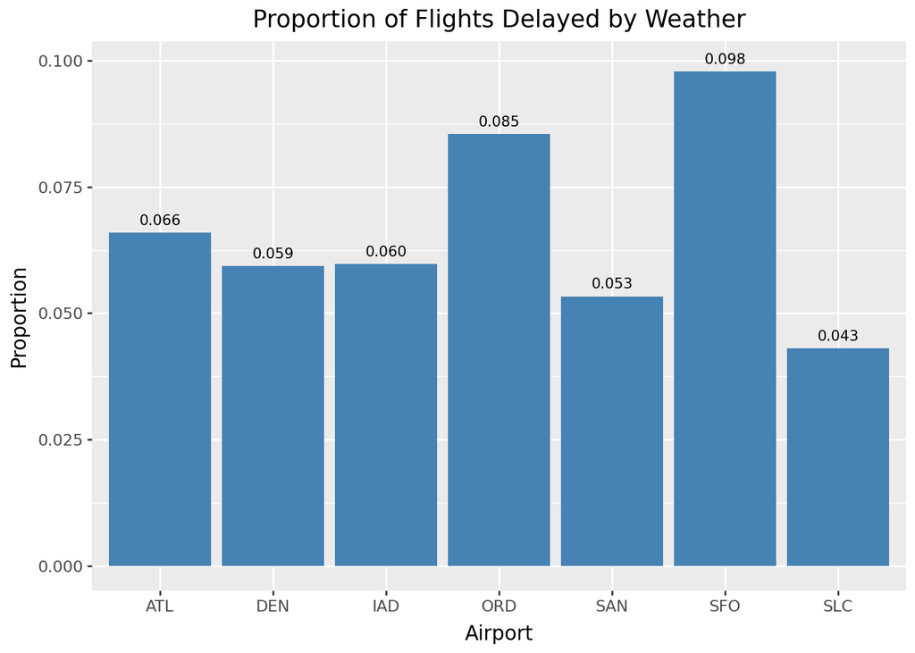

```python
# Include and execute your code here
import pandas as pd
import numpy as np
#using plotline for visuals and readability of plots, and easier to understand data
from plotnine import ggplot, aes, geom_bar, labs, theme, element_text, geom_text

# Load the data from the URL
url = "https://raw.githubusercontent.com/byuidatascience/data4missing/master/data-raw/flights_missing/flights_missing.json"
df = pd.read_json(url)

# Standardize missing values
missing_values = ["", " ", "-999", "1500+"]
df.replace(missing_values, np.nan, inplace=True)

# Calculate mean for late aircraft delays and replace NaN
late_aircraft_mean = df['num_of_delays_late_aircraft'].mean()
df['num_of_delays_late_aircraft'] = df['num_of_delays_late_aircraft'].fillna(late_aircraft_mean)

# Define weather delay function
def calc_weather_delays(row):
    weather = row['num_of_delays_weather']
    late = row['num_of_delays_late_aircraft'] * 0.3
    nas_factor = 0.4 if row['month'] in ['April', 'May', 'June', 'July', 'August'] else 0.65
    nas = row['num_of_delays_nas'] * nas_factor
    return weather + late + nas

# Apply to create new column
df['total_weather_delays'] = df.apply(calc_weather_delays, axis=1)

# Calculate proportion by airport
weather_summary = df.groupby('airport_code').agg({
    'num_of_flights_total': 'sum',
    'total_weather_delays': 'sum'
}).reset_index()
weather_summary['prop_weather_delayed'] = weather_summary['total_weather_delays'] / weather_summary['num_of_flights_total']

# Format the proportions for display
weather_summary['prop_formatted'] = weather_summary['prop_weather_delayed'].apply(lambda x: f'{x:.3f}')

# Sort by proportion for better visualization
weather_summary = weather_summary.sort_values('prop_weather_delayed')

# Plot
plot = (ggplot(weather_summary, aes(x='airport_code', y='prop_weather_delayed'))
        + geom_bar(stat='identity', fill='steelblue')
        + geom_text(aes(label='prop_formatted'), va='bottom', size=8, nudge_y=0.001)
        + labs(title='Proportion of Flights Delayed by Weather',
               x='Airport',
               y='Proportion')
        + theme(axis_text_x=element_text(rotation=0)))
plot.show()
```

## STRETCH QUESTION|TASK 1

**Which delay is the worst delay?** Create a similar analysis as above for Weahter Delay with: Carrier Delay and Security Delay. Compare the proportion of delay for each of the three categories in a Chart and a Table. Describe your results.

Table:

```python
import pandas as pd
import numpy as np
# I chose to use seaborn and IPython mostly for asethetics
import seaborn as sns
import matplotlib.pyplot as plt
from IPython.display import display

# Set seaborn style for better aesthetics
sns.set_style("whitegrid")

# Load data
url = "https://raw.githubusercontent.com/byuidatascience/data4missing/master/data-raw/flights_missing/flights_missing.json"
df = pd.read_json(url)

# Standardize missing values
missing_values = ["", " ", "-999", "1500+"]
df.replace(missing_values, np.nan, inplace=True)

# Calculate mean for late aircraft delays and replace NaN, ensuring numeric type first
df['num_of_delays_late_aircraft'] = pd.to_numeric(df['num_of_delays_late_aircraft'], errors='coerce')
late_aircraft_mean = df['num_of_delays_late_aircraft'].mean()
df['num_of_delays_late_aircraft'].fillna(late_aircraft_mean, inplace=True)

# Define weather delay function with input validation
def calc_weather_delays(row):
    weather = pd.to_numeric(row['num_of_delays_weather'], errors='coerce') or 0
    late = (pd.to_numeric(row['num_of_delays_late_aircraft'], errors='coerce') or 0) * 0.3
    nas = pd.to_numeric(row['num_of_delays_nas'], errors='coerce') or 0
    nas_factor = 0.4 if row['month'] in ['April', 'May', 'June', 'July', 'August'] else 0.65
    return weather + late + (nas * nas_factor)

# Apply to create new column as asked in problem
df['total_weather_delays'] = df.apply(calc_weather_delays, axis=1)

# Ensure numeric columns, handling any remaining non-numeric values
numeric_columns = [
    "num_of_flights_total",
    "total_weather_delays",
    "num_of_delays_carrier",
    "num_of_delays_security",
]
df[numeric_columns] = df[numeric_columns].apply(pd.to_numeric, errors="coerce").fillna(0)

# Calculate proportions with a check for division by zero - just in case  -
delay_summary = df.groupby('airport_code').agg({
    'num_of_flights_total': 'sum',
    'total_weather_delays': 'sum',
    'num_of_delays_carrier': 'sum',
    'num_of_delays_security': 'sum'
}).reset_index()

# Avoid division by zero
delay_summary['Weather'] = delay_summary['total_weather_delays'] / delay_summary['num_of_flights_total'].replace(0, np.nan)
delay_summary['Carrier'] = delay_summary['num_of_delays_carrier'] / delay_summary['num_of_flights_total'].replace(0, np.nan)
delay_summary['Security'] = delay_summary['num_of_delays_security'] / delay_summary['num_of_flights_total'].replace(0, np.nan)

# Select columns for the table
delay_table = delay_summary[['airport_code', 'Weather', 'Carrier', 'Security']]

# Format the proportion columns as percentages
delay_table['Weather'] = delay_table['Weather'].apply(lambda x: f'{x:.1%}' if pd.notna(x) else 'NaN')
delay_table['Carrier'] = delay_table['Carrier'].apply(lambda x: f'{x:.1%}' if pd.notna(x) else 'NaN')
delay_table['Security'] = delay_table['Security'].apply(lambda x: f'{x:.3%}' if pd.notna(x) else 'NaN')


# Display the table
display(delay_table)
```

|  | airport_code | Weather | Carrier | Security |
| --- | --- | --- | --- | --- |
| 0 | ATL | 6.6% | 2.2% | 0.019% |
| 1 | DEN | 5.9% | 4.5% | 0.039% |
| 2 | IAD | 6.0% | 5.6% | 0.032% |
| 3 | ORD | 8.5% | 3.4% | 0.024% |
| 4 | SAN | 5.3% | 6.2% | 0.053% |
| 5 | SFO | 9.8% | 5.3% | 0.043% |
| 6 | SLC | 4.3% | 4.5% | 0.062% |

Chart:

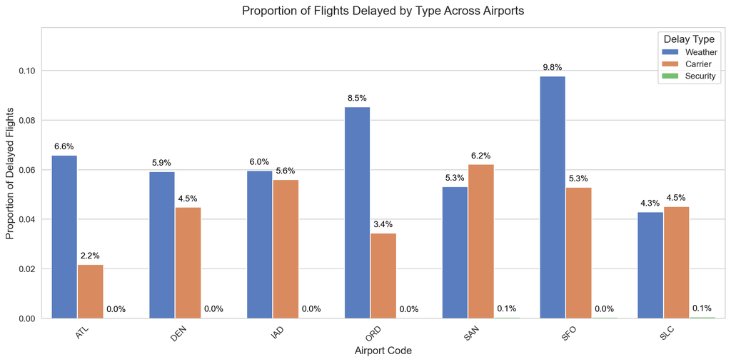

```python
# Include and execute your code here
import seaborn as sns
import matplotlib.pyplot as plt


# Melt for plotting
# Melt transforms data frame into long format
delay_melt = delay_summary.melt(id_vars=['airport_code'],
                                value_vars=['Weather', 'Carrier', 'Security'],
                                var_name='delay_type', value_name='proportion')

# Set seaborn style
sns.set_style("whitegrid")

# Plot with improved aesthetics
plt.figure(figsize=(12, 6))
ax = sns.barplot(data=delay_melt, x='airport_code', y='proportion', hue='delay_type', palette='muted')

# Add value labels
for p in ax.patches:
    height = p.get_height()
    if height > 0:
        ax.annotate(f'{height:.1%}',
                    (p.get_x() + p.get_width() / 2., height),
                    ha='center', va='bottom', fontsize=10, color='black', xytext=(0, 5),
                    textcoords='offset points')

# Customize plot
plt.title('Proportion of Flights Delayed by Type Across Airports', fontsize=14, pad=15)
plt.xlabel('Airport Code', fontsize=12)
plt.ylabel('Proportion of Delayed Flights', fontsize=12)
plt.xticks(rotation=45, ha='right')
plt.legend(title='Delay Type', title_fontsize=12, fontsize=10)
plt.ylim(0, delay_melt['proportion'].max() * 1.2)
plt.tight_layout()

# Display plot
plt.show()
```